# Caso Práctico 06: BMW vs Volkswagen

Ignacio Ruiz de Zuazu Echevarría

27/11/2020

[link a GitHub](https://github.com/ignacio-ruiz-de-zuazu/Prediccion-practicas.git)

[figure not shown]

## Descripción y objetivos del trabajo

Utilizando datos diarios de los dos series desde el año 2014, debemos analizar la relación entre BMW y Volkswagen, contestando a las siguiente preguntas:

- ¿Estimar el modelo garch de BMW?
- Plantear un modelo VAR mensual entre los dos activos.

## Exploración de los datos

Se ha recogido los rendimientos diarios de las dos cotizaciones y se han excluido todos los valores pérdidos que no se han podido recoger en el dataset. En primer lugar, vamos a observar la evolución y el comportamiento de las cotizaciones de ambas series y se va a estudiar sus rendimientos y sus posibles variaciones.

### Análisis de BMW

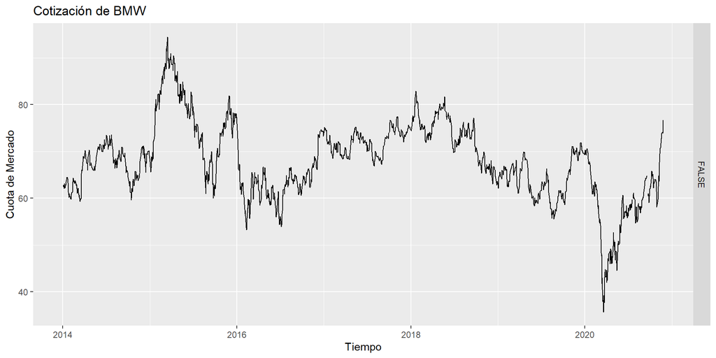

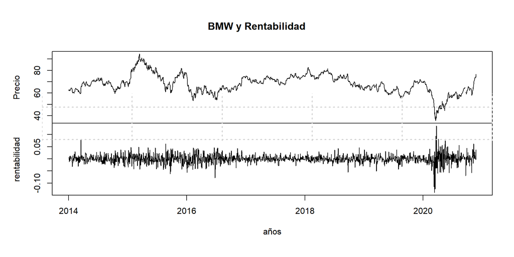

En estas gráficas podemos ver que los rendimientos de BMW sufren dos tendencias que se podrían considerar atípicas, un pico ascendente en 2015, periodo en el que BMW cerró el año con un aumento del 10% en los beneficios, hasta sobrepasar los 6.000 millones de euros por primera vez (6.396 millones), respecto a los 5.817 que alcanzó en 2014. Además, registra un nuevo récord hasta la fecha para los volúmenes de ventas. Este periodo también coincide con la bajada en las ventas de uno de sus competidores como es Volkswagen. Otro de los cambios de tendencia con un pico bajista es el que ha sufrido en 2020 a causa del coronavirus.

### Gráficas de Volkswagen

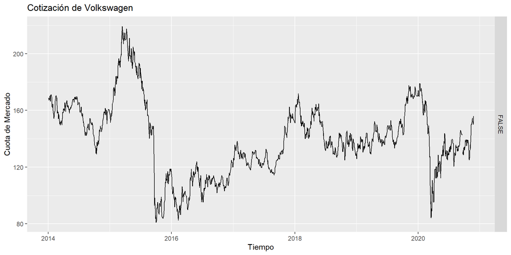

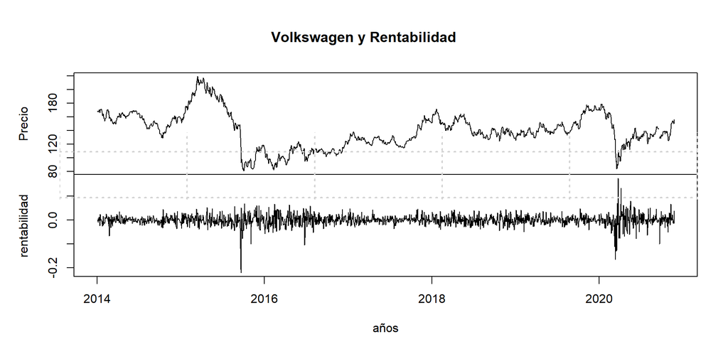

Al igual que BMW, Volkswagen sufre dos cambios de tendencia significantes en 2015 y 2020, ambas negativas. En 2015 salió a la luz que Volkswagen había instalado ilegalmente un software para alterar los resultados de los controles técnicos de emisiones contaminantes en 11 millones de automóviles con motor diésel, vendidos entre 2009 y 2015. Como resultado de dicho fraude, sus motores habían superado con creces los estándares de la Agencia de Protección Ambiental de Estados Unidos. En 2020 se vio afectada por la pandemia.

## Investigar un modelo GARCH para BMW

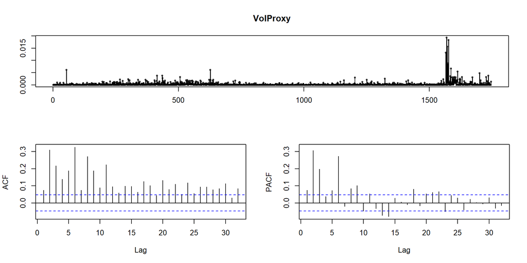

Con esta gráfica podemos ver que la volatilidad de BMW no es ruido blanco ya que sus valores se encuentran fuera de las bandas, por lo que realizar un modelo GARCH en este caso sería lo más apropiado.

### Test de Lagrange

```
##
## Call:
## lm(formula = atsq ~ x)
##
## Residuals:
##        Min         1Q     Median         3Q        Max
## -0.0047719 -0.0002216 -0.0001073  0.0000522  0.0181218
##
## Coefficients:
##               Estimate Std. Error t value Pr(>|t|)
## (Intercept)  0.0000898  0.0000256   3.507 0.000464 ***
## x1          -0.0367091  0.0241898  -1.518 0.129315
## x2           0.2365680  0.0242030   9.774  < 2e-16 ***
## x3           0.0928796  0.0248211   3.742 0.000189 ***
## x4          -0.0115348  0.0249254  -0.463 0.643587
## x5           0.0845979  0.0249186   3.395 0.000702 ***
## x6           0.2479274  0.0250053   9.915  < 2e-16 ***
## x7          -0.0227848  0.0256288  -0.889 0.374111
## x8           0.1235828  0.0255516   4.837 1.44e-06 ***
## x9           0.0750661  0.0257088   2.920 0.003548 **
## x10         -0.0412466  0.0257119  -1.604 0.108859
## x11          0.0788966  0.0257162   3.068 0.002189 **
## x12         -0.0448780  0.0258371  -1.737 0.082575 .
## x13         -0.0846044  0.0257036  -3.292 0.001017 **
## x14         -0.0894033  0.0257829  -3.468 0.000538 ***
## x15          0.0183294  0.0251310   0.729 0.465887
## x16         -0.0121155  0.0250696  -0.483 0.628962
## x17         -0.0074174  0.0250702  -0.296 0.767370
## x18          0.0678835  0.0249983   2.716 0.006684 **
## x19         -0.0141094  0.0243582  -0.579 0.562500
## x20          0.0549062  0.0244001   2.250 0.024560 *
## ---
## Signif. codes:  0 '***' 0.001 '**' 0.01 '*' 0.05 '.' 0.1 ' ' 1
##
## Residual standard error: 0.0008744 on 1705 degrees of freedom
## Multiple R-squared:  0.2416, Adjusted R-squared:  0.2327
## F-statistic: 27.15 on 20 and 1705 DF,  p-value: < 2.2e-16
```

Se observa que el p-valor es inferior al nivel de significación por lo que existe la posibilidad de realizar un modelo GARCH.

En primer lugar realizaremos un modelo ARCH 1

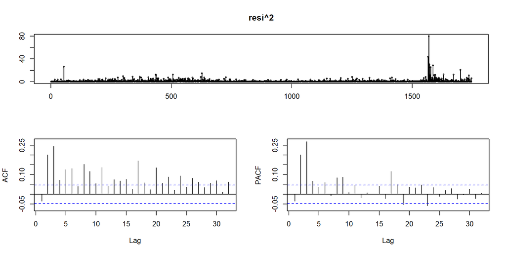

Al analizar los errores, se observa que éstos siguen teniendo errores GARCH, por lo que se propone un modelo GARCH (1,1).

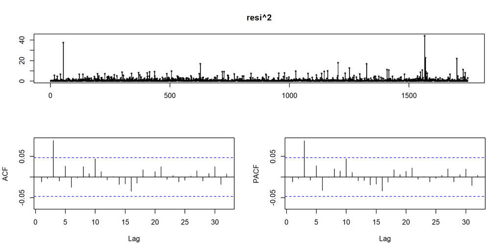

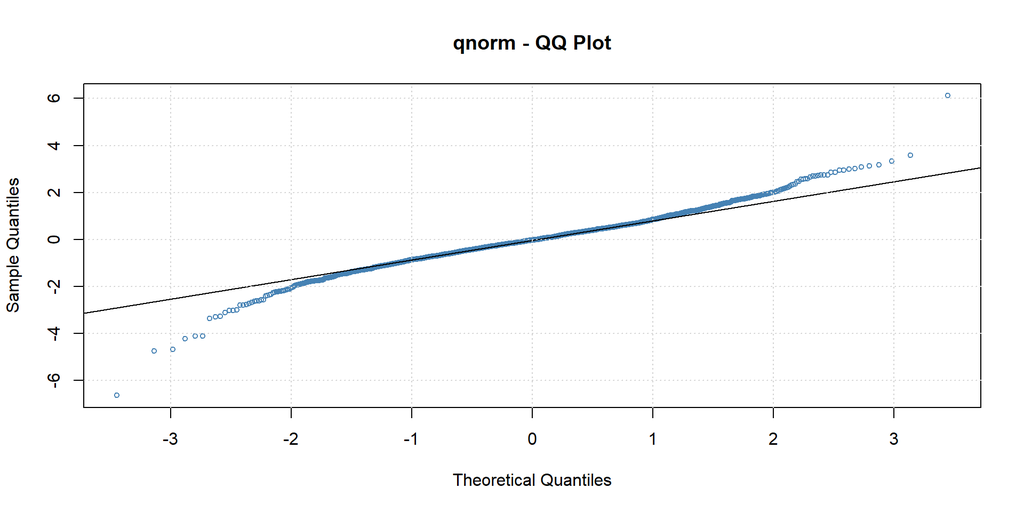

### t-student

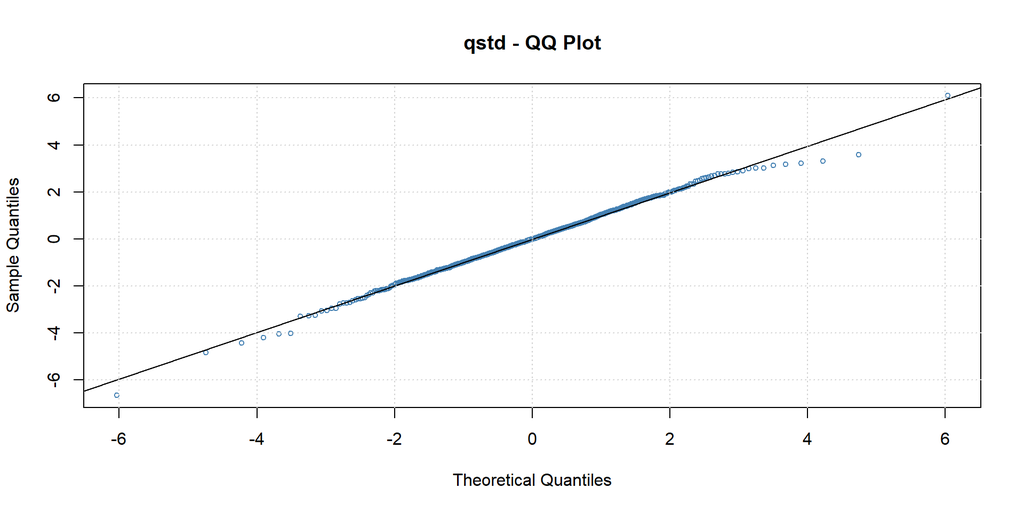

El qq plot tiene muchos menos puntos que antes a pesar de que sigue teniendo algún atípico. Los problemas siempre vienen en las caídas negativas en finanzas.

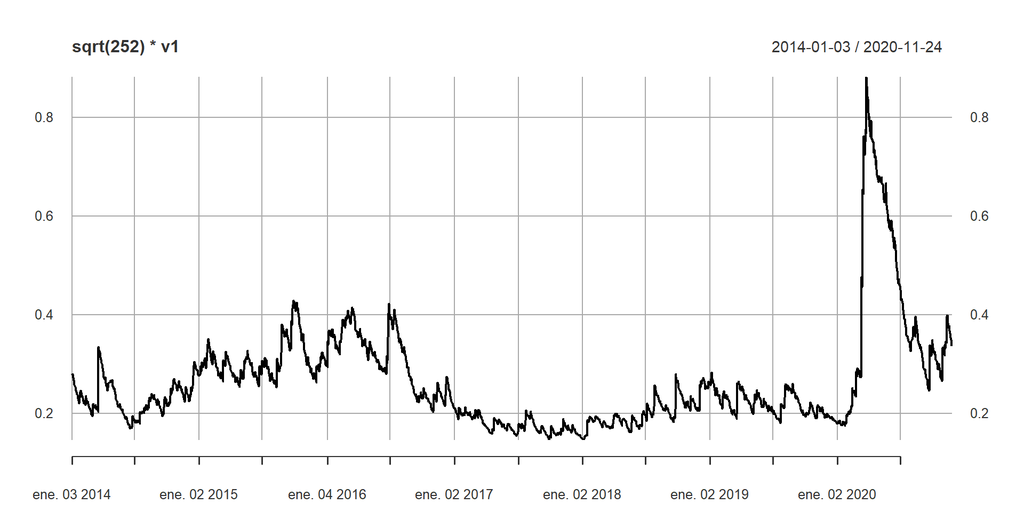

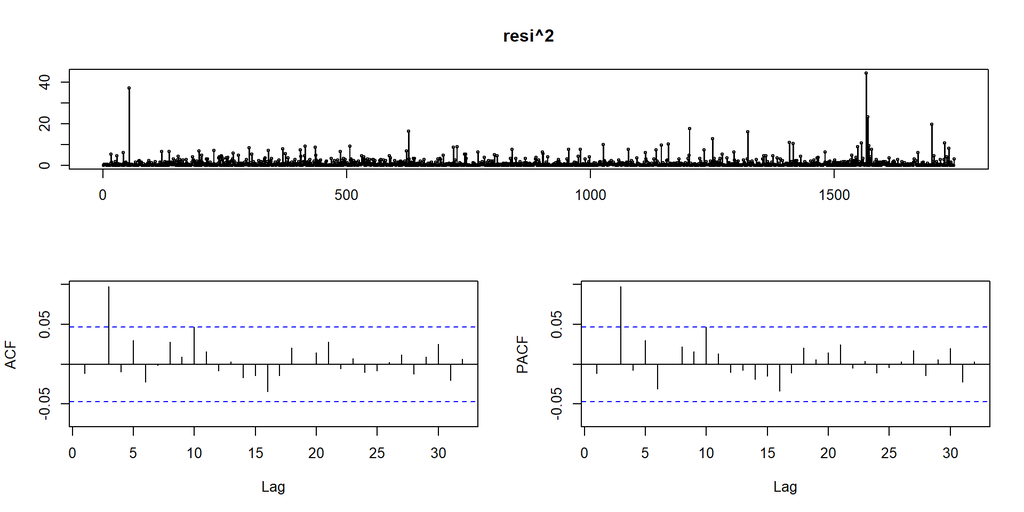

Sigue habiendo errores que no son ruido blanco, esto se puede deber a que a la hora de realizar las predicciones y la reciente situación de coronavirus que ha supuesto un cambio significante en la evolucion de los rendimientos de BMW pueda afectar a nuestro modelo de predicción.

### Predicción modelo GARCH

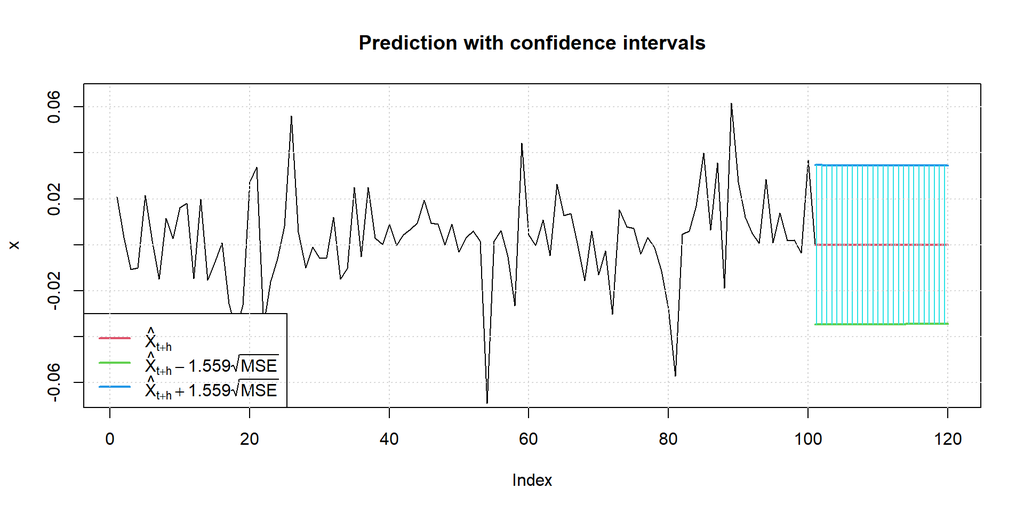

```
##    meanForecast  meanError standardDeviation lowerInterval upperInterval
## 1  1.915174e-05 0.02221970        0.02221970   -0.03463016    0.03466847
## 2  1.915174e-05 0.02221341        0.02221341   -0.03462036    0.03465866
## 3  1.915174e-05 0.02220715        0.02220715   -0.03461060    0.03464890
## 4  1.915174e-05 0.02220092        0.02220092   -0.03460088    0.03463918
## 5  1.915174e-05 0.02219471        0.02219471   -0.03459120    0.03462950
## 6  1.915174e-05 0.02218853        0.02218853   -0.03458157    0.03461987
## 7  1.915174e-05 0.02218238        0.02218238   -0.03457198    0.03461028
## 8  1.915174e-05 0.02217626        0.02217626   -0.03456243    0.03460073
## 9  1.915174e-05 0.02217016        0.02217016   -0.03455292    0.03459122
## 10 1.915174e-05 0.02216409        0.02216409   -0.03454345    0.03458176
## 11 1.915174e-05 0.02215805        0.02215805   -0.03453403    0.03457234
## 12 1.915174e-05 0.02215203        0.02215203   -0.03452465    0.03456295
## 13 1.915174e-05 0.02214605        0.02214605   -0.03451531    0.03455361
## 14 1.915174e-05 0.02214008        0.02214008   -0.03450601    0.03454432
## 15 1.915174e-05 0.02213415        0.02213415   -0.03449675    0.03453506
## 16 1.915174e-05 0.02212824        0.02212824   -0.03448754    0.03452584
## 17 1.915174e-05 0.02212235        0.02212235   -0.03447836    0.03451666
## 18 1.915174e-05 0.02211649        0.02211649   -0.03446923    0.03450753
## 19 1.915174e-05 0.02211066        0.02211066   -0.03446013    0.03449843
## 20 1.915174e-05 0.02210485        0.02210485   -0.03445108    0.03448938
```

## Plantear un modelo VAR mensual entre los dos activos

En primer lugar se obtienen los rendimientos mensuales de ambas series temporales

```
##                     BMW   Volkswagen
## 2014-02-28  0.040970422  0.005039200
## 2014-03-31  0.084454743 -0.004773286
## 2014-04-30 -0.015841912  0.031399733
## 2014-05-30  0.050911190  0.026037993
## 2014-06-30  0.005738941 -0.016546249
## 2014-07-31 -0.036055720 -0.094241987
```

### Estimamos el modelo VAR

```
##
## VAR Estimation Results:
## =========================
## Endogenous variables: BMW, Volkswagen
## Deterministic variables: const
## Sample size: 81
## Log Likelihood: 185.739
## Roots of the characteristic polynomial:
## 0.2778 0.2778
## Call:
## VAR(y = bmw_vw)
##
##
## Estimation results for equation BMW:
## ====================================
## BMW = BMW.l1 + Volkswagen.l1 + const
##
##                Estimate Std. Error t value Pr(>|t|)
## BMW.l1         0.252956   0.159222   1.589  0.11617
## Volkswagen.l1 -0.309527   0.112774  -2.745  0.00751 **
## const          0.001628   0.008822   0.185  0.85406
## ---
## Signif. codes:  0 '***' 0.001 '**' 0.01 '*' 0.05 '.' 0.1 ' ' 1
##
##
## Residual standard error: 0.07936 on 78 degrees of freedom
## Multiple R-Squared: 0.08984, Adjusted R-squared: 0.06651
## F-statistic:  3.85 on 2 and 78 DF,  p-value: 0.02544
##
##
## Estimation results for equation Volkswagen:
## ===========================================
## Volkswagen = BMW.l1 + Volkswagen.l1 + const
##
##                 Estimate Std. Error t value Pr(>|t|)
## BMW.l1         0.5165835  0.2173241   2.377   0.0199 *
## Volkswagen.l1 -0.3270804  0.1539267  -2.125   0.0368 *
## const         -0.0009931  0.0120413  -0.082   0.9345
## ---
## Signif. codes:  0 '***' 0.001 '**' 0.01 '*' 0.05 '.' 0.1 ' ' 1
##
##
## Residual standard error: 0.1083 on 78 degrees of freedom
## Multiple R-Squared: 0.07263, Adjusted R-squared: 0.04885
## F-statistic: 3.054 on 2 and 78 DF,  p-value: 0.05283
##
##
##
## Covariance matrix of residuals:
##                 BMW Volkswagen
## BMW        0.006297   0.006017
## Volkswagen 0.006017   0.011732
##
## Correlation matrix of residuals:
##            BMW Volkswagen
## BMW        1.0        0.7
## Volkswagen 0.7        1.0
```

### Causalidad de granger

```r
causality(model.var1)
```

```
## $Granger
##
##  Granger causality H0: BMW do not Granger-cause Volkswagen
##
## data:  VAR object model.var1
## F-Test = 5.7167, df1 = 1, df2 = 158, p-value = 0.01798
##
##
## $Instant
##
##  H0: No instantaneous causality between: BMW and Volkswagen
##
## data:  VAR object model.var1
## Chi-squared = 26.618, df = 1, p-value = 2.479e-07
```

A continuación observaremos la respuesta a un impulso, es decir, como afectaría una subida de BMW como afectaría a Volkswagen. Solo podemos ver los efectos que tiene una variable sobre otra.

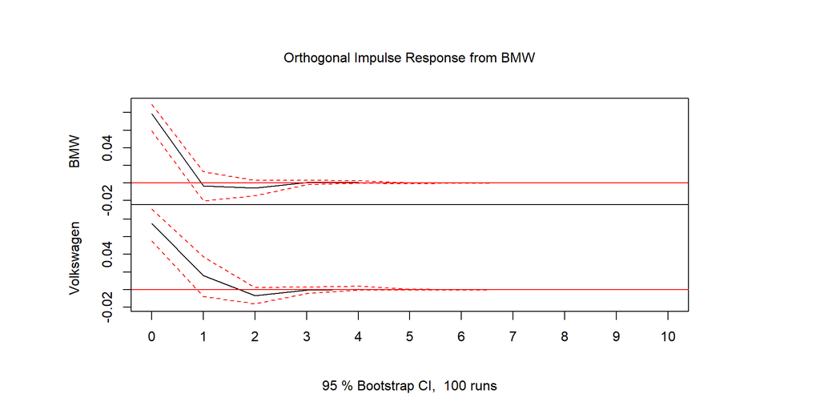

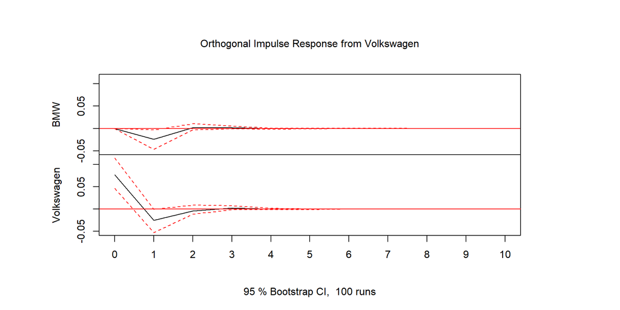

### Predicción modelo VAR

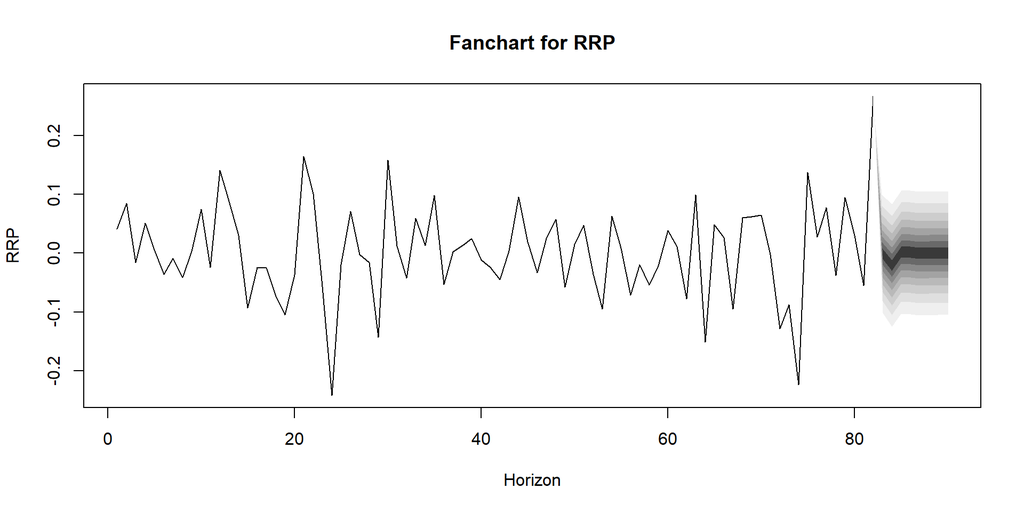

## Conclusiones

Las conclusiones que obtenemos es que para BMW se puede realizar un modelo GARCH (1,1) sobre los rendimientos diarios mientras que para analizar los rendimientos mensuales de las dos series podemos realizar modelos VAR ya que tienen relaciones dinámicas. En cuanto a las dos series podemos concluir que siguen una misma tendencia dentro del mercado de automóviles, mientras Volkswagen tuvo el escándalo de emisiones contaminantes en 2015 que le llevó a una bajada significativa de sus ingresos, BMW se mantuvo dentro del mercadi y en ese año llegó a su pico en cuanto a la cifra de ingresos. Se podrá afirmar que de las malas decisiones de una empresa se pudo aprovechar otra. Aunque también si miramos en el año 2020 vemos que ambas tienen un comportamiento negativo debido a la pandemia. Esto puede ser un hecho significativo a la hora de realizar predicciones ya que la información más importante para hacer estas predicciones se basa en el corto plazo, entonces el comportamiento de la serie se explicaría a partir de un impulso.